# Lab 9: CNL and Count Models

### *Some of the issues with Poisson models and how to solve them*

1. **Overdispersion**: This means that the Var(Y)>E(Y), which causes incorrect standard errors. There are multiple ways to see if there is overdispersion in our data. Let’s see two visual diagnostics and a formal test for overdispersion.
1. Plot $\hat\mu$ versus $(y-\hat\mu)$. This would give us a sense if there is overdispersion. It won’t really tell us how to deal with it but it would give us information about te presence of the phenomenon.

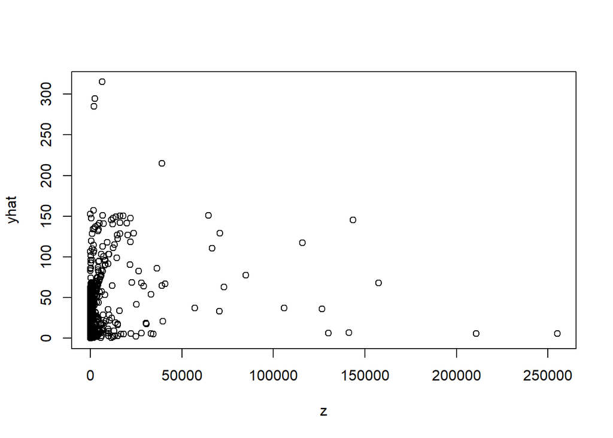

```r
# plot \mu_hat vs (y-\muhat)^2
yhat <- predict(m2, type="response")
z <- (y-yhat)^2
plot(z, yhat)
```

2. The rootgrams. This is a canned function, and in fact you need to install it from the web since it is not available for newer versions of R. (This is why we don’t like canned functions). Here the x-axis are the counts of the events. The y-axis s the square root of the frequency. Bins below zero means our model is underpredicting these counts. Bins that don’t reach to zero, imply that counts are being overpredicting. What is happening here?

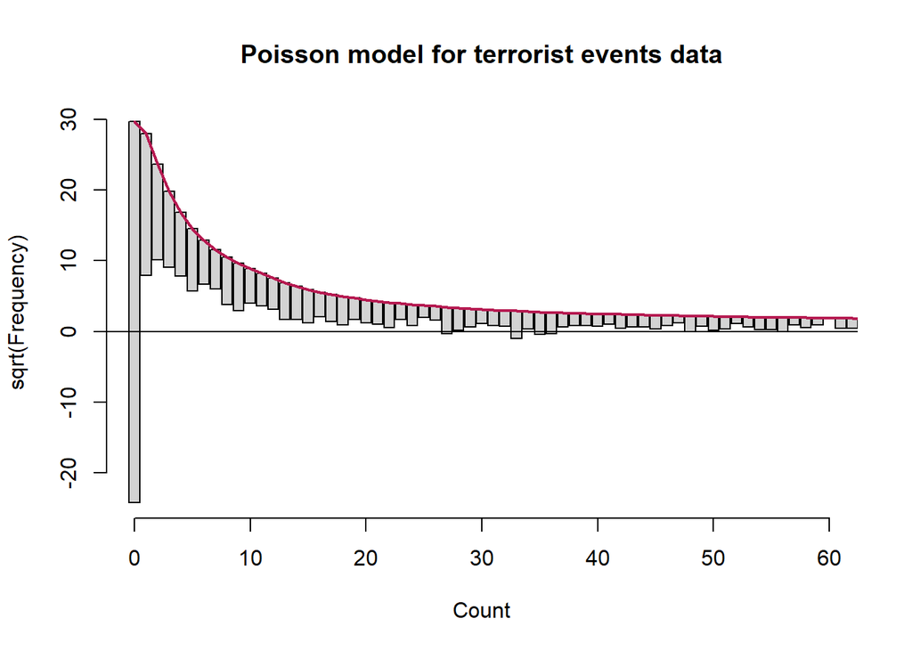

```r
# Rootgrams#
# install.packages("countreg", repos="http://R-Forge.R-project.org")
library(countreg)
rootogram(m2, main="Poisson model for terrorist events data", xlab="Count", xlim=c(0,60)) #for Poisson model
```

3. The formal test.

$H_o:$ No overdispersion

$H_a:$ There is overdispersion

$$\sum_{i=1}^n z_i = \sum_{i=1}^n \left(\frac{y_i-\hat y}{\sqrt{\hat y}}\right)^2\sim\chi^2_{n-k}$$
Where n is the number of observations in our sample and k the number of parameters (intercept included)

```r
# Calculate needed values for the statistic
yhat <- predict(m2, type="response")                     # predicted values, how would you calculate this "manually"?
z <- (terrorism$FGTDDom - yhat)/sqrt(yhat)
n <- length(y)
k <- ncol(X)

# Compare the result with a chi squared distribution
1 - pchisq(sum(z^2), n-k)
```

```
## [1] 0
```

We now know there is overdispersion. The solution is to run a negative binomial model. This will account for the overdispersion. See the slides for the mathematical logic. Here we use the *glm.nb* function from the **MASS** package.

```r
# calculating the model
m3 <- glm.nb(FGTDDom ~ Durable + GINI + logGNI + logpop + logarea + AggSF + ColdWar + dome_confl + inal_confl +
            democracy + personalist + oneparty + monarchy + hybrid,
          data=terrorism)

summary(m3)
```

```
##
## Call:
## glm.nb(formula = FGTDDom ~ Durable + GINI + logGNI + logpop +
##     logarea + AggSF + ColdWar + dome_confl + inal_confl + democracy +
##     personalist + oneparty + monarchy + hybrid, data = terrorism,
##     init.theta = 0.1761598034, link = log)
##
## Deviance Residuals:
##     Min       1Q   Median       3Q      Max
## -1.7585  -0.8955  -0.6929  -0.3158   6.1103
##
## Coefficients:
##              Estimate Std. Error z value Pr(>|z|)
## (Intercept) -4.327159   0.495340  -8.736  < 2e-16 ***
## Durable     -0.014734   0.001635  -9.011  < 2e-16 ***
## GINI         0.051668   0.005776   8.945  < 2e-16 ***
## logGNI       0.512733   0.035160  14.583  < 2e-16 ***
## logpop       0.898485   0.038540  23.313  < 2e-16 ***
## logarea     -0.179499   0.030062  -5.971 2.36e-09 ***
## AggSF        0.275089   0.029035   9.474  < 2e-16 ***
## ColdWar      0.372242   0.082033   4.538 5.69e-06 ***
## dome_confl   0.244882   0.076569   3.198  0.00138 **
## inal_confl   0.676921   0.058685  11.535  < 2e-16 ***
## democracy   -0.425241   0.155033  -2.743  0.00609 **
## personalist -1.134236   0.173787  -6.527 6.73e-11 ***
## oneparty    -1.220637   0.154738  -7.888 3.06e-15 ***
## monarchy    -2.030174   0.228320  -8.892  < 2e-16 ***
## hybrid      -1.361240   0.255486  -5.328 9.93e-08 ***
## ---
## Signif. codes:  0 '***' 0.001 '**' 0.01 '*' 0.05 '.' 0.1 ' ' 1
##
## (Dispersion parameter for Negative Binomial(0.1762) family taken to be 1)
##
##     Null deviance: 5186.8  on 4489  degrees of freedom
## Residual deviance: 3168.6  on 4475  degrees of freedom
## AIC: 15817
##
## Number of Fisher Scoring iterations: 1
##
##
##               Theta:  0.17616
##           Std. Err.:  0.00568
## Warning while fitting theta: alternation limit reached
##
##  2 x log-likelihood:  -15784.57000
```

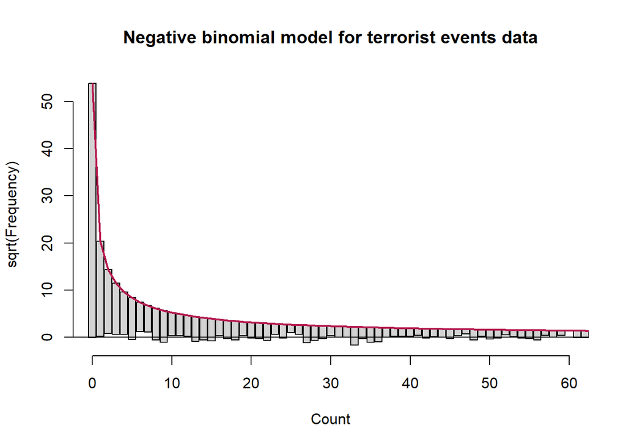

```r
# Chekc the rootogram
rootogram(m3, main="Negative binomial model for terrorist events data", xlab="Count", xlim=c(0,60))
```

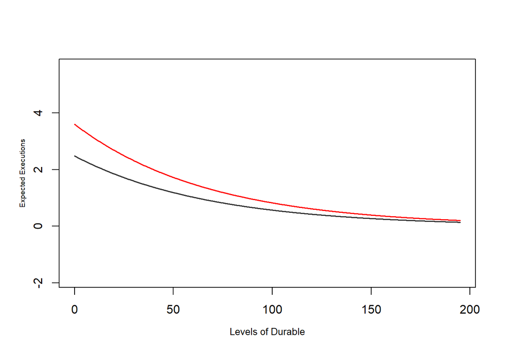

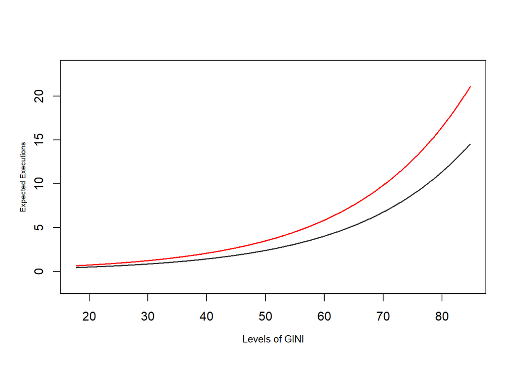

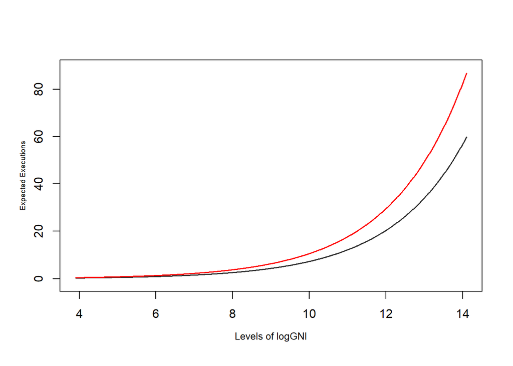

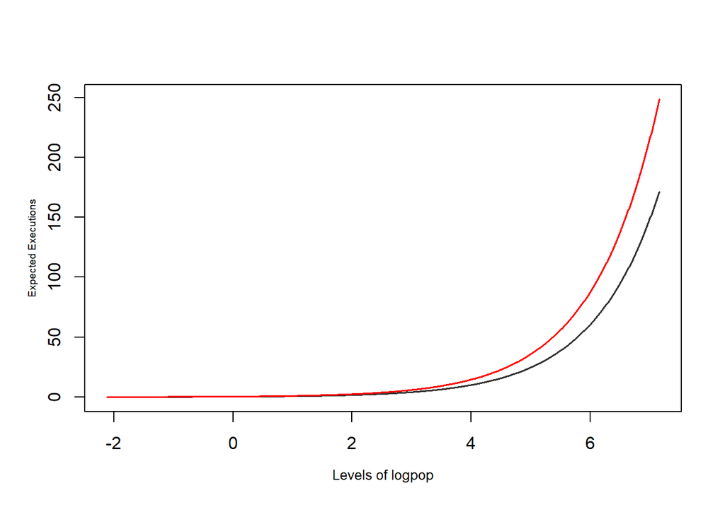

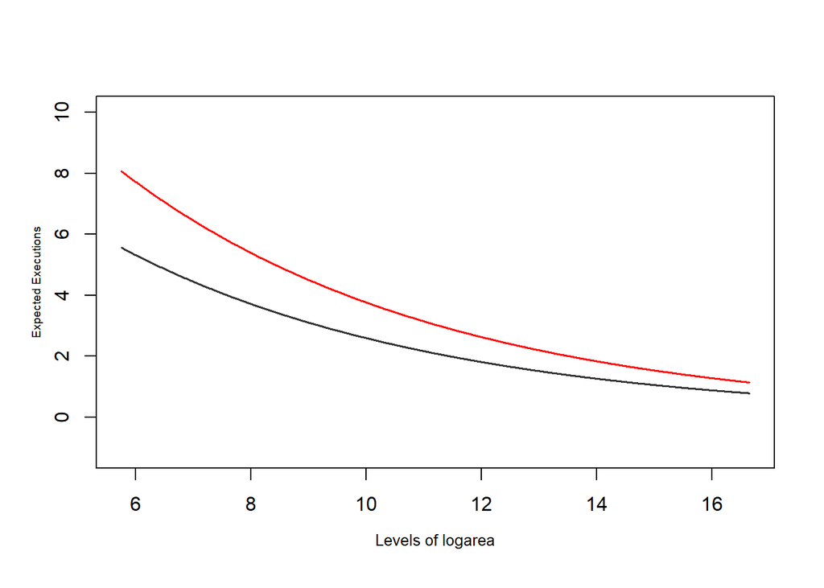

[figure not shown]

```r
# Let's do some plots for some of the continous variables
X <- cbind(1, terrorism[3:16])
dimnames(X)[[2]] <- names(m3$coeff)
X1 <- X0 <- X
X0[, "ColdWar"] <- 0
X1[, "ColdWar"] <- 1

for (i in c(2,3,4,5,6)) {
  ruler <- seq(min(X0[,i]), max(X0[,i]), length = 1000)
  xb0 <- exp(as.vector(m3$coeff[-i] %*% apply(X0[,-i], 2, mean))
  + m3$coeff[i] * ruler)
  xb1 <- exp(as.vector(m3$coeff[-i] %*% apply(X1[,-i], 2, mean))
  + m3$coeff[i] * ruler)
  plot(ruler, xb0, type="l", lwd = 1.5, col = "gray20",
  xlab="",ylab="", ylim = c(min(xb0, xb1) - 2, max(xb0, xb1) + 2))
  lines(ruler, xb1, lwd = 1.5, col = "red")
  mtext(side = 1, paste("Levels of", dimnames(X0)[[2]][i]), cex=0.8, line=2.5)
  mtext(side = 2,"Expected Executions", cex=0.6, line = 2.2)
}
```

2. **Too many zeros**: There might be the case where you have very rare events in your dataset which leads to a large number of zeros. Even more than the ones being calculated by the Poisson or the Negative Binomial models. This could be the result of two different data generation processes. For instance, if someone asks you how many of the additional resources from our labs have you consulted in the last three days. Some people will answer zero and think “What addiitonal resources section?”. Other students, really like the additional resources, but haven’t used any in the past three days hence they will also respond zero. This causes some issues with your coefficients. In this cases you might want to estimate a [hurdle](https://data.library.virginia.edu/getting-started-with-hurdle-models/) or a [zero inflated](https://stats.idre.ucla.edu/r/dae/zip/) model.

## **Additional Resources**

- Piazza has a more recent [paper](https://www.tandfonline.com/doi/pdf/10.1080/09546553.2014.994061?casa_token=4JTM6E09zYAAAAAA:qBWTfvgIfXDoQ10LCsZeLaP61bsuBFKC7sFcDWm0lVSVGH9MCiemi44-WAj5dKuBe6_oSyNIFdU) about terrorism using count models
- Check this articles from [Holland](https://onlinelibrary.wiley.com/doi/abs/10.1111/ajps.12125) that also use these models
- See the links for the hurdle and zero inflated models in their respective sections.
- Some R references to count and discrete data from [Friendly and Meyer](http://ddar.datavis.ca/pages/using)
- Some more explanation of rootgrams [here](https://arxiv.org/pdf/1605.01311.pdf)